# Logistics Delivery Analytics Platform

End-to-End ETL Pipeline & Operational Analytics Report

# 1 Executive Summary

This project analyzes delivery performance data to identify the operational factors associated with delivery speed, cost, and efficiency.

The final dataset was produced through an end-to-end data pipeline involving Azure Blob Storage and MS SQL Server.

The analysis evaluates:

- Delivery partner performance
- Delivery costs and cost efficiency
- Weather and traffic conditions
- Provincial and city-level performance
- Distance and delivery-time relationships
- Average delivery speed

Overall Delivery Performance Indicators

| Metric | Value |
| --- | --- |
| Total Deliveries | 42 |
| Average Delivery Time | 1.9 hours |
| Average Delivery Cost | $130.95 |
| Average Distance | 77.7 km |
| Average Cost per Kilometre | $1.67 |
| Average Delivery Speed | 44 km/h |

# 2 Project Architecture

The project follows this workflow:

**Raw Delivery Data → Azure Blob Storage → SQL ETL → Reporting Fact Table → R Markdown Analysis**

Azure SQL was used to transform the data, remove invalid records, enrich transactions with weather and traffic conditions, and calculate reporting metrics.

The final `fact_delivery_performance` table was exported as a CSV and analyzed in R.

# 3 Data Overview

Dataset Overview

| Measurement | Result |
| --- | --- |
| Rows | 42 |
| Columns | 15 |
| Unique Delivery Partners | 5 |
| Unique Cities | 5 |
| Unique Provinces | 2 |
| Earliest Order Date | January 03, 2026 |
| Latest Delivery Date | March 30, 2026 |

Sample of Final Reporting Data

| delivery_id | order_date | delivery_date | partner | city | province | weather | traffic_level | distance_km | delivery_time_hours | cost |
| --- | --- | --- | --- | --- | --- | --- | --- | --- | --- | --- |
| D001 | 2026-01-22 | 2026-01-26 | UPS | Hamilton | QC | Rain | Low | 45.8 | 0.84 | 61.31 |
| D002 | 2026-03-09 | 2026-03-11 | FedEx | Brampton | ON | Rain | High | 58.8 | 1.29 | 125.35 |
| D003 | 2026-01-30 | 2026-02-01 | UPS | Hamilton | ON | Sunny | Medium | 149.6 | 2.94 | 250.49 |
| D004 | 2026-02-12 | 2026-02-17 | Amazon Logistics | Toronto | QC | Cloudy | Low | 21.8 | 0.37 | 28.37 |
| D005 | 2026-01-12 | 2026-01-13 | UPS | Ottawa | ON | Rain | High | 28.4 | 0.56 | 36.82 |
| D007 | 2026-03-02 | 2026-03-07 | Purolator | Ottawa | QC | Snow | Medium | 54.5 | 1.81 | 80.64 |
| D008 | 2026-02-27 | 2026-03-04 | FedEx | Toronto | QC | Rain | Medium | 149.3 | 3.87 | 195.08 |
| D009 | 2026-03-05 | 2026-03-06 | DHL | Hamilton | QC | Snow | Medium | 84.8 | 1.66 | 160.41 |
| D012 | 2026-01-05 | 2026-01-10 | Purolator | Toronto | ON | Rain | High | 138.1 | 4.50 | 310.47 |
| D013 | 2026-03-04 | 2026-03-09 | DHL | Hamilton | QC | Snow | Medium | 40.8 | 0.73 | 48.56 |

# 4 Data Quality Validation

Final Dataset Quality Checks

| Check | Records |
| --- | --- |
| Missing Delivery IDs | 0 |
| Duplicate Delivery IDs | 0 |
| Missing Partner Values | 0 |
| Missing Delivery Times | 0 |
| Missing Costs | 0 |
| Missing Weather Values | 0 |
| Missing Traffic Values | 0 |
| Invalid Distances | 0 |
| Invalid Costs | 0 |

The validation results confirm whether the final reporting dataset contains duplicate identifiers, missing business-critical fields, or invalid numerical values.

# 5 Delivery Partner Performance

Delivery Partner Performance Summary

| Partner | Deliveries | Average Delivery Time (Hours) | Average Cost | Average Cost per KM | Average Speed (KM/H) |
| --- | --- | --- | --- | --- | --- |
| Amazon Logistics | 7 | 1.09 | $90.90 | $1.88 | 45.73 |
| DHL | 11 | 1.79 | $114.44 | $1.57 | 43.81 |
| FedEx | 9 | 2.09 | $155.39 | $1.66 | 47.43 |
| Purolator | 6 | 2.14 | $134.07 | $1.74 | 38.19 |
| UPS | 9 | 2.30 | $155.76 | $1.61 | 43.09 |

## 5.1 Average Delivery Time by Partner

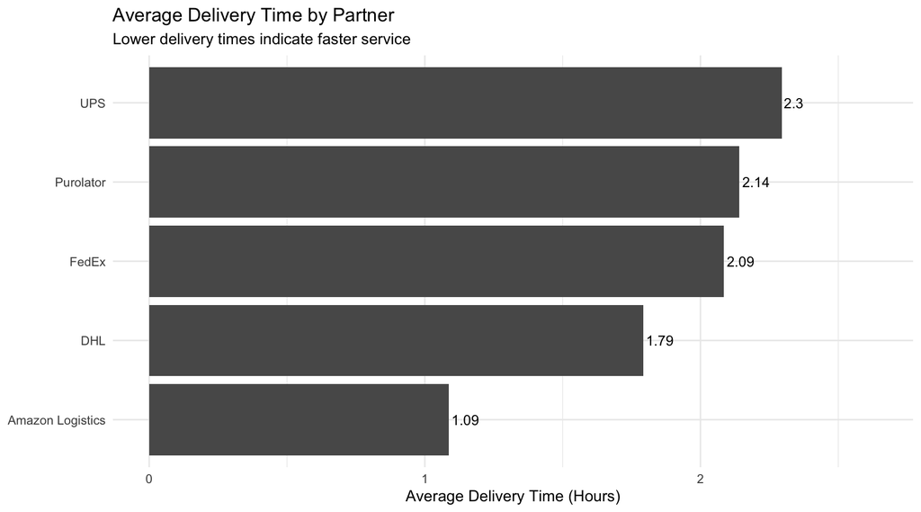

**Finding:** Amazon Logistics had the lowest average delivery time at 1.09 hours across 7 deliveries.

## 5.2 Average Delivery Cost by Partner

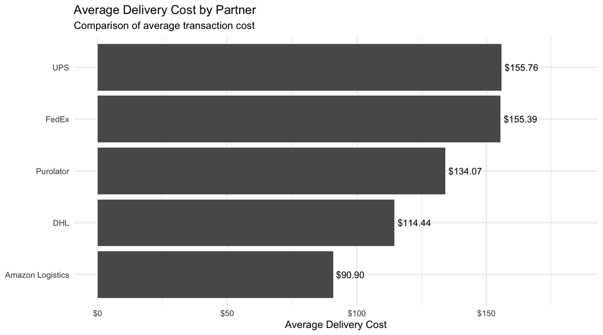

## 5.3 Cost Efficiency by Partner

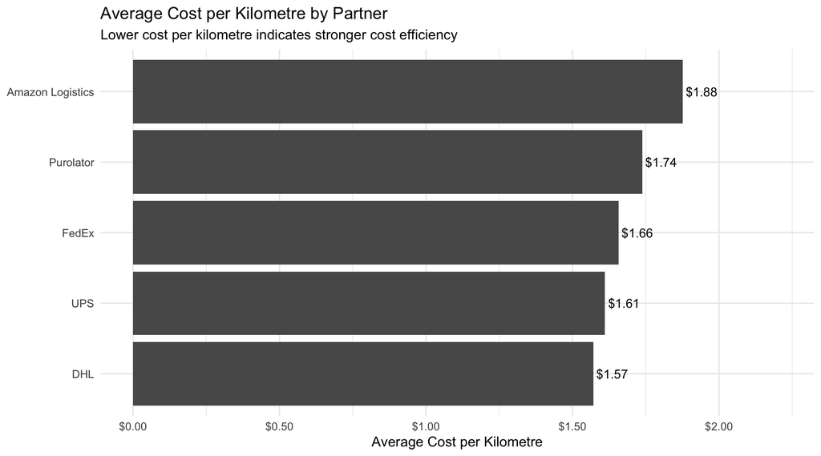

**Finding:** DHL had the lowest average cost per kilometre at $1.57 per kilometre.

# 6 Weather Impact

Performance by Weather Condition

| Weather | Deliveries | Average Delivery Time (Hours) | Average Speed (KM/H) | Average Cost |
| --- | --- | --- | --- | --- |
| Cloudy | 4 | 1.44 | 54.00 | $135.32 |
| Rain | 15 | 1.67 | 43.72 | $113.05 |
| Snow | 19 | 2.05 | 42.39 | $133.84 |
| Sunny | 4 | 2.46 | 42.20 | $179.99 |

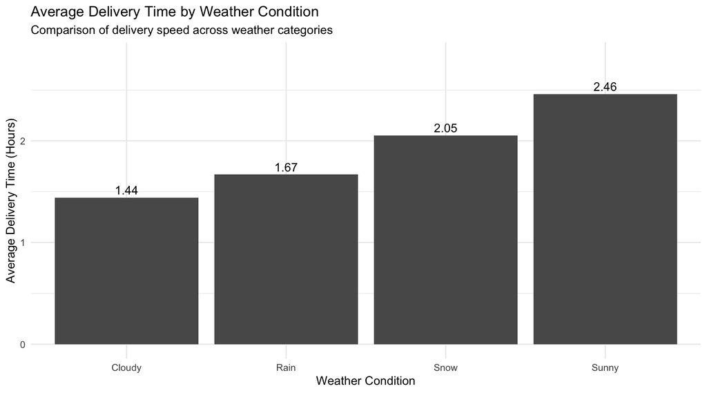

# 7 Traffic Impact

Performance by Traffic Level

| Traffic Level | Deliveries | Average Delivery Time (Hours) | Average Speed (KM/H) | Average Cost |
| --- | --- | --- | --- | --- |
| Low | 8 | 1.45 | 47.73 | $96.20 |
| Medium | 21 | 2.07 | 43.52 | $145.25 |
| High | 13 | 1.89 | 42.32 | $129.24 |

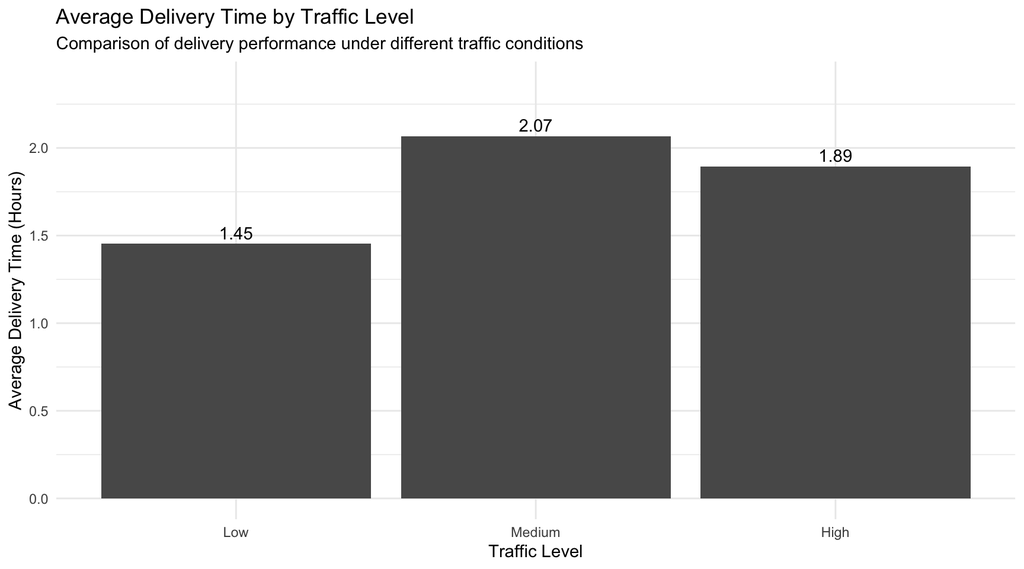

# 8 Provincial Performance

Provincial Delivery Performance

| Province | Deliveries | Average Delivery Time (Hours) | Average Cost | Average Distance (KM) | Average Speed (KM/H) |
| --- | --- | --- | --- | --- | --- |
| QC | 21 | 1.82 | $116.08 | 73.78 | 43.22 |
| ON | 21 | 1.98 | $145.82 | 81.59 | 44.69 |

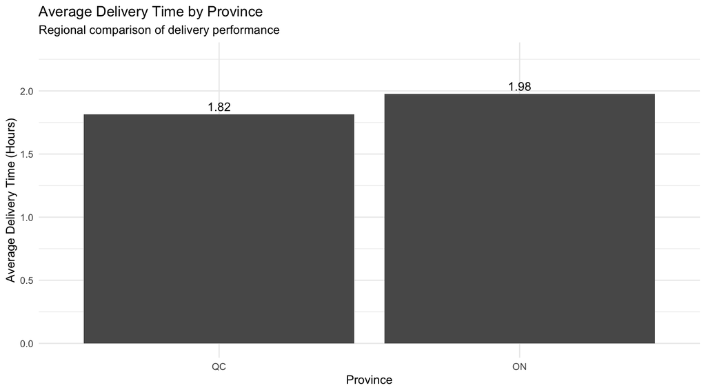

# 9 City-Level Performance

City-Level Delivery Performance

| City | Deliveries | Average Delivery Time (Hours) | Average Cost | Average Speed (KM/H) |
| --- | --- | --- | --- | --- |
| Mississauga | 3 | 1.55 | $116.96 | 52.98 |
| Hamilton | 10 | 1.78 | $144.07 | 48.52 |
| Toronto | 10 | 1.83 | $137.34 | 45.08 |
| Brampton | 10 | 2.03 | $119.75 | 41.64 |
| Ottawa | 9 | 2.05 | $126.39 | 37.18 |

# 10 Distance and Delivery Time

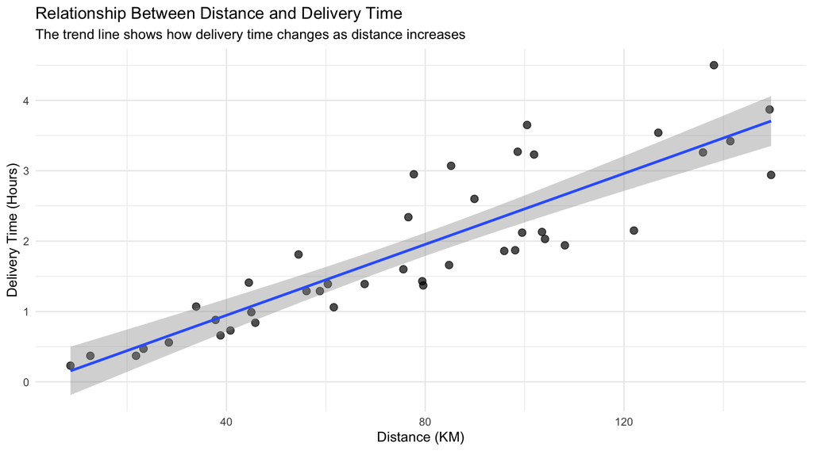

**Finding:** The correlation between delivery distance and delivery time is 0.88 .

# 11 Distance and Cost

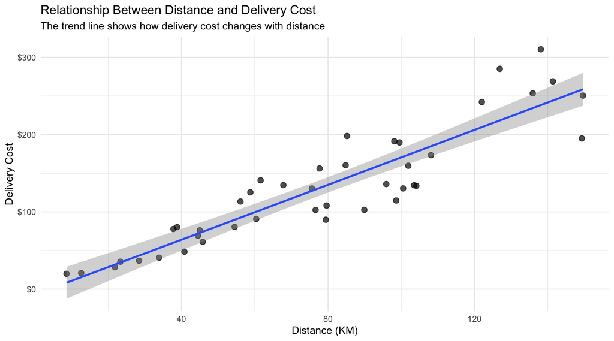

**Finding:** The correlation between delivery distance and delivery cost is 0.91 .

# 12 Delivery Speed Analysis

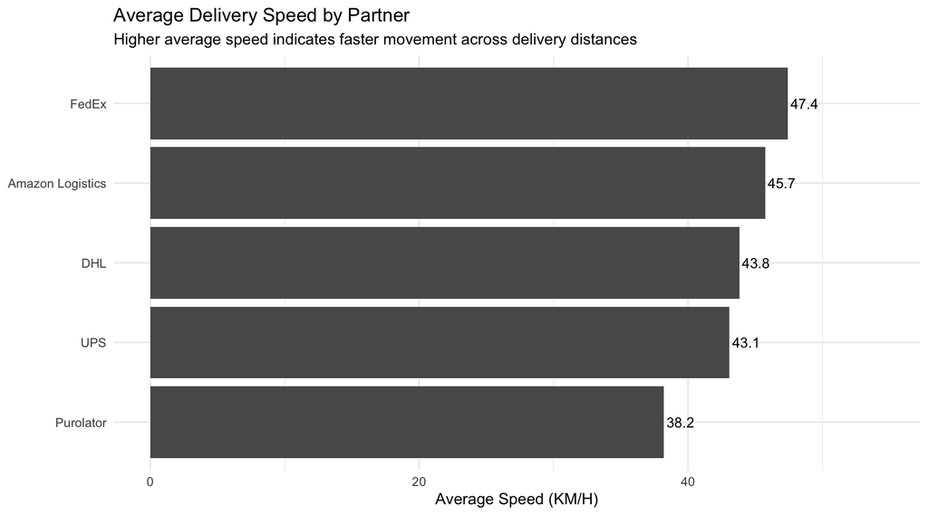

# 13 Key Findings

1. **Fastest delivery partner:** Amazon Logistics recorded the lowest average delivery time of 1.09 hours.
2. **Slowest delivery partner:** UPS recorded the highest average delivery time of 2.3 hours.
3. **Lowest average delivery cost:** Amazon Logistics had an average cost of $90.90.
4. **Strongest cost efficiency:** DHL recorded the lowest average cost per kilometre at $1.57.
5. **Highest delivery speed:** FedEx recorded an average speed of 47.43 km/h.
6. **Weather condition with the longest delivery time:** Sunny averaged 2.46 hours.
7. **Traffic condition with the longest delivery time:** Medium traffic averaged 2.07 hours.
8. **Fastest province:** QC recorded the lowest average delivery time of 1.82 hours.

# 14 Business Recommendations

1. **Prioritize high-performing partners.** Use delivery time, delivery speed, and cost-per-kilometre metrics together when assigning shipments.
2. **Investigate inefficient partners.** Partners with higher costs and slower delivery times should be reviewed for route, capacity, or service issues.
3. **Include weather and traffic in delivery planning.** Historical condition data can support more realistic delivery estimates and proactive customer communication.
4. **Use distance-based pricing controls.** Cost-per-kilometre should be monitored to identify expensive routes and pricing inconsistencies.
5. **Review regional performance.** Provinces or cities with slower average delivery times may require route redesign, additional carrier capacity, or improved scheduling.
6. **Expand future data collection.** Future versions should include promised delivery dates, delay reasons, package types, customer ratings, and delivery status to support stronger service-level analysis.

# 15 Limitations

The analysis is based on a small synthetic dataset and should be interpreted as a demonstration of data engineering and analytical methods rather than a production logistics assessment.

The dataset does not contain a promised delivery deadline or an explicit on-time indicator. Therefore, the report compares delivery speed and efficiency rather than calculating an official on-time delivery rate.

Weather and traffic records were joined using the closest available condition record within the same province, with preference given to matching cities. This approach reduced missing matches but may not represent the exact conditions at the delivery time.

# 16 Conclusion

This project demonstrates a complete analytics workflow from raw logistics data to a final business intelligence report.

Python was used for initial data cleaning, Azure SQL supported ETL and reporting-table creation, and R was used to evaluate carrier performance, cost efficiency, regional patterns, weather, traffic, distance, and delivery speed.

The resulting workflow provides a reusable foundation for larger logistics datasets and more advanced forecasting or optimization models.